# Explore Movie Dataset

## 探索电影数据集

在这个项目中，你将尝试使用所学的知识，使用 `NumPy`、`Pandas`、`matplotlib`、`seaborn` 库中的函数，来对电影数据集进行探索。

下载数据集： [TMDb电影数据](https://s3.cn-north-1.amazonaws.com.cn/static-documents/nd101/explore+dataset/tmdb-movies.csv)

数据集各列名称的含义：

| 列名称 | id | imdb_id | popularity | budget | revenue | original_title | cast | homepage | director | tagline | keywords | overview | runtime | genres | production_companies | release_date | vote_count | vote_average | release_year | budget_adj | revenue_adj |
| --- | --- | --- | --- | --- | --- | --- | --- | --- | --- | --- | --- | --- | --- | --- | --- | --- | --- | --- | --- | --- | --- |
| 含义 | 编号 | IMDB 编号 | 知名度 | 预算 | 票房 | 名称 | 主演 | 网站 | 导演 | 宣传词 | 关键词 | 简介 | 时常 | 类别 | 发行公司 | 发行日期 | 投票总数 | 投票均值 | 发行年份 | 预算（调整后） | 票房（调整后） |

**请注意，你需要提交该报告导出的 `.html`、`.ipynb` 以及 `.py` 文件。**

## 第一节 数据的导入与处理

在这一部分，你需要编写代码，使用 Pandas 读取数据，并进行预处理。

**任务1.1：** 导入库以及数据

1. 载入需要的库 `NumPy`、`Pandas`、`matplotlib`、`seaborn`。
2. 利用 `Pandas` 库，读取 `tmdb-movies.csv` 中的数据，保存为 `movie_data`。

提示：记得使用 notebook 中的魔法指令 `%matplotlib inline`，否则会导致你接下来无法打印出图像。

```python
import numpy as np
import pandas as pd
import matplotlib.pyplot as plt
import seaborn as sb

%matplotlib inline
movie_data = pd.read_csv('./tmdb-movies.csv')
movie_data
```

|  | id | imdb_id | popularity | budget | revenue | original_title | cast | homepage | director | tagline | ... | overview | runtime | genres | production_companies | release_date | vote_count | vote_average | release_year | budget_adj | revenue_adj |
| --- | --- | --- | --- | --- | --- | --- | --- | --- | --- | --- | --- | --- | --- | --- | --- | --- | --- | --- | --- | --- | --- |
| 0 | 135397 | tt0369610 | 32.985763 | 150000000 | 1513528810 | Jurassic World | Chris Pratt\|Bryce Dallas Howard\|Irrfan Khan\|Vi... | http://www.jurassicworld.com/ | Colin Trevorrow | The park is open. | ... | Twenty-two years after the events of Jurassic ... | 124 | Action\|Adventure\|Science Fiction\|Thriller | Universal Studios\|Amblin Entertainment\|Legenda... | 6/9/15 | 5562 | 6.5 | 2015 | 1.379999e+08 | 1.392446e+09 |
| 1 | 76341 | tt1392190 | 28.419936 | 150000000 | 378436354 | Mad Max: Fury Road | Tom Hardy\|Charlize Theron\|Hugh Keays-Byrne\|Nic... | http://www.madmaxmovie.com/ | George Miller | What a Lovely Day. | ... | An apocalyptic story set in the furthest reach... | 120 | Action\|Adventure\|Science Fiction\|Thriller | Village Roadshow Pictures\|Kennedy Miller Produ... | 5/13/15 | 6185 | 7.1 | 2015 | 1.379999e+08 | 3.481613e+08 |
| 2 | 262500 | tt2908446 | 13.112507 | 110000000 | 295238201 | Insurgent | Shailene Woodley\|Theo James\|Kate Winslet\|Ansel... | http://www.thedivergentseries.movie/#insurgent | Robert Schwentke | One Choice Can Destroy You | ... | Beatrice Prior must confront her inner demons ... | 119 | Adventure\|Science Fiction\|Thriller | Summit Entertainment\|Mandeville Films\|Red Wago... | 3/18/15 | 2480 | 6.3 | 2015 | 1.012000e+08 | 2.716190e+08 |
| 3 | 140607 | tt2488496 | 11.173104 | 200000000 | 2068178225 | Star Wars: The Force Awakens | Harrison Ford\|Mark Hamill\|Carrie Fisher\|Adam D... | http://www.starwars.com/films/star-wars-episod... | J.J. Abrams | Every generation has a story. | ... | Thirty years after defeating the Galactic Empi... | 136 | Action\|Adventure\|Science Fiction\|Fantasy | Lucasfilm\|Truenorth Productions\|Bad Robot | 12/15/15 | 5292 | 7.5 | 2015 | 1.839999e+08 | 1.902723e+09 |
| 4 | 168259 | tt2820852 | 9.335014 | 190000000 | 1506249360 | Furious 7 | Vin Diesel\|Paul Walker\|Jason Statham\|Michelle ... | http://www.furious7.com/ | James Wan | Vengeance Hits Home | ... | Deckard Shaw seeks revenge against Dominic Tor... | 137 | Action\|Crime\|Thriller | Universal Pictures\|Original Film\|Media Rights ... | 4/1/15 | 2947 | 7.3 | 2015 | 1.747999e+08 | 1.385749e+09 |
| 5 | 281957 | tt1663202 | 9.110700 | 135000000 | 532950503 | The Revenant | Leonardo DiCaprio\|Tom Hardy\|Will Poulter\|Domhn... | http://www.foxmovies.com/movies/the-revenant | Alejandro González Iñárritu | (n. One who has returned, as if from the dead.) | ... | In the 1820s, a frontiersman, Hugh Glass, sets... | 156 | Western\|Drama\|Adventure\|Thriller | Regency Enterprises\|Appian Way\|CatchPlay\|Anony... | 12/25/15 | 3929 | 7.2 | 2015 | 1.241999e+08 | 4.903142e+08 |
| 6 | 87101 | tt1340138 | 8.654359 | 155000000 | 440603537 | Terminator Genisys | Arnold Schwarzenegger\|Jason Clarke\|Emilia Clar... | http://www.terminatormovie.com/ | Alan Taylor | Reset the future | ... | The year is 2029. John Connor, leader of the r... | 125 | Science Fiction\|Action\|Thriller\|Adventure | Paramount Pictures\|Skydance Productions | 6/23/15 | 2598 | 5.8 | 2015 | 1.425999e+08 | 4.053551e+08 |
| 7 | 286217 | tt3659388 | 7.667400 | 108000000 | 595380321 | The Martian | Matt Damon\|Jessica Chastain\|Kristen Wiig\|Jeff ... | http://www.foxmovies.com/movies/the-martian | Ridley Scott | Bring Him Home | ... | During a manned mission to Mars, Astronaut Mar... | 141 | Drama\|Adventure\|Science Fiction | Twentieth Century Fox Film Corporation\|Scott F... | 9/30/15 | 4572 | 7.6 | 2015 | 9.935996e+07 | 5.477497e+08 |
| 8 | 211672 | tt2293640 | 7.404165 | 74000000 | 1156730962 | Minions | Sandra Bullock\|Jon Hamm\|Michael Keaton\|Allison... | http://www.minionsmovie.com/ | Kyle Balda\|Pierre Coffin | Before Gru, they had a history of bad bosses | ... | Minions Stuart, Kevin and Bob are recruited by... | 91 | Family\|Animation\|Adventure\|Comedy | Universal Pictures\|Illumination Entertainment | 6/17/15 | 2893 | 6.5 | 2015 | 6.807997e+07 | 1.064192e+09 |
| 9 | 150540 | tt2096673 | 6.326804 | 175000000 | 853708609 | Inside Out | Amy Poehler\|Phyllis Smith\|Richard Kind\|Bill Ha... | http://movies.disney.com/inside-out | Pete Docter | Meet the little voices inside your head. | ... | Growing up can be a bumpy road, and it's no ex... | 94 | Comedy\|Animation\|Family | Walt Disney Pictures\|Pixar Animation Studios\|W... | 6/9/15 | 3935 | 8.0 | 2015 | 1.609999e+08 | 7.854116e+08 |
| 10 | 206647 | tt2379713 | 6.200282 | 245000000 | 880674609 | Spectre | Daniel Craig\|Christoph Waltz\|Léa Seydoux\|Ralp... | http://www.sonypictures.com/movies/spectre/ | Sam Mendes | A Plan No One Escapes | ... | A cryptic message from Bond’s past sends him... | 148 | Action\|Adventure\|Crime | Columbia Pictures\|Danjaq\|B24 | 10/26/15 | 3254 | 6.2 | 2015 | 2.253999e+08 | 8.102203e+08 |
| 11 | 76757 | tt1617661 | 6.189369 | 176000003 | 183987723 | Jupiter Ascending | Mila Kunis\|Channing Tatum\|Sean Bean\|Eddie Redm... | http://www.jupiterascending.com | Lana Wachowski\|Lilly Wachowski | Expand your universe. | ... | In a universe where human genetic material is ... | 124 | Science Fiction\|Fantasy\|Action\|Adventure | Village Roadshow Pictures\|Dune Entertainment\|A... | 2/4/15 | 1937 | 5.2 | 2015 | 1.619199e+08 | 1.692686e+08 |
| 12 | 264660 | tt0470752 | 6.118847 | 15000000 | 36869414 | Ex Machina | Domhnall Gleeson\|Alicia Vikander\|Oscar Isaac\|S... | http://exmachina-movie.com/ | Alex Garland | There is nothing more human than the will to s... | ... | Caleb, a 26 year old coder at the world's larg... | 108 | Drama\|Science Fiction | DNA Films\|Universal Pictures International (UP... | 1/21/15 | 2854 | 7.6 | 2015 | 1.379999e+07 | 3.391985e+07 |
| 13 | 257344 | tt2120120 | 5.984995 | 88000000 | 243637091 | Pixels | Adam Sandler\|Michelle Monaghan\|Peter Dinklage\|... | http://www.pixels-movie.com/ | Chris Columbus | Game On. | ... | Video game experts are recruited by the milita... | 105 | Action\|Comedy\|Science Fiction | Columbia Pictures\|Happy Madison Productions | 7/16/15 | 1575 | 5.8 | 2015 | 8.095996e+07 | 2.241460e+08 |
| 14 | 99861 | tt2395427 | 5.944927 | 280000000 | 1405035767 | Avengers: Age of Ultron | Robert Downey Jr.\|Chris Hemsworth\|Mark Ruffalo... | http://marvel.com/movies/movie/193/avengers_ag... | Joss Whedon | A New Age Has Come. | ... | When Tony Stark tries to jumpstart a dormant p... | 141 | Action\|Adventure\|Science Fiction | Marvel Studios\|Prime Focus\|Revolution Sun Studios | 4/22/15 | 4304 | 7.4 | 2015 | 2.575999e+08 | 1.292632e+09 |
| 15 | 273248 | tt3460252 | 5.898400 | 44000000 | 155760117 | The Hateful Eight | Samuel L. Jackson\|Kurt Russell\|Jennifer Jason ... | http://thehatefuleight.com/ | Quentin Tarantino | No one comes up here without a damn good reason. | ... | Bounty hunters seek shelter from a raging bliz... | 167 | Crime\|Drama\|Mystery\|Western | Double Feature Films\|The Weinstein Company\|Fil... | 12/25/15 | 2389 | 7.4 | 2015 | 4.047998e+07 | 1.432992e+08 |
| 16 | 260346 | tt2446042 | 5.749758 | 48000000 | 325771424 | Taken 3 | Liam Neeson\|Forest Whitaker\|Maggie Grace\|Famke... | http://www.taken3movie.com/ | Olivier Megaton | It Ends Here | ... | Ex-government operative Bryan Mills finds his ... | 109 | Crime\|Action\|Thriller | Twentieth Century Fox Film Corporation\|M6 Film... | 1/1/15 | 1578 | 6.1 | 2015 | 4.415998e+07 | 2.997096e+08 |
| 17 | 102899 | tt0478970 | 5.573184 | 130000000 | 518602163 | Ant-Man | Paul Rudd\|Michael Douglas\|Evangeline Lilly\|Cor... | http://marvel.com/movies/movie/180/ant-man | Peyton Reed | Heroes Don't Get Any Bigger | ... | Armed with the astonishing ability to shrink i... | 115 | Science Fiction\|Action\|Adventure | Marvel Studios | 7/14/15 | 3779 | 7.0 | 2015 | 1.195999e+08 | 4.771138e+08 |
| 18 | 150689 | tt1661199 | 5.556818 | 95000000 | 542351353 | Cinderella | Lily James\|Cate Blanchett\|Richard Madden\|Helen... | NaN | Kenneth Branagh | Midnight is just the beginning. | ... | When her father unexpectedly passes away, youn... | 112 | Romance\|Fantasy\|Family\|Drama | Walt Disney Pictures\|Genre Films\|Beagle Pug Fi... | 3/12/15 | 1495 | 6.8 | 2015 | 8.739996e+07 | 4.989630e+08 |
| 19 | 131634 | tt1951266 | 5.476958 | 160000000 | 650523427 | The Hunger Games: Mockingjay - Part 2 | Jennifer Lawrence\|Josh Hutcherson\|Liam Hemswor... | http://www.thehungergames.movie/ | Francis Lawrence | The fire will burn forever. | ... | With the nation of Panem in a full scale war, ... | 136 | War\|Adventure\|Science Fiction | Studio Babelsberg\|StudioCanal\|Lionsgate\|Walt D... | 11/18/15 | 2380 | 6.5 | 2015 | 1.471999e+08 | 5.984813e+08 |
| 20 | 158852 | tt1964418 | 5.462138 | 190000000 | 209035668 | Tomorrowland | Britt Robertson\|George Clooney\|Raffey Cassidy\|... | http://movies.disney.com/tomorrowland | Brad Bird | Imagine a world where nothing is impossible. | ... | Bound by a shared destiny, a bright, optimisti... | 130 | Action\|Family\|Science Fiction\|Adventure\|Mystery | Walt Disney Pictures\|Babieka\|A113 | 5/19/15 | 1899 | 6.2 | 2015 | 1.747999e+08 | 1.923127e+08 |
| 21 | 307081 | tt1798684 | 5.337064 | 30000000 | 91709827 | Southpaw | Jake Gyllenhaal\|Rachel McAdams\|Forest Whitaker... | NaN | Antoine Fuqua | Believe in Hope. | ... | Billy "The Great" Hope, the reigning junior mi... | 123 | Action\|Drama | Escape Artists\|Riche-Ludwig Productions | 6/15/15 | 1386 | 7.3 | 2015 | 2.759999e+07 | 8.437300e+07 |
| 22 | 254128 | tt2126355 | 4.907832 | 110000000 | 470490832 | San Andreas | Dwayne Johnson\|Alexandra Daddario\|Carla Gugino... | http://www.sanandreasmovie.com/ | Brad Peyton | A rescue pilot survived an earthquake, this is... | ... | In the aftermath of a massive earthquake in Ca... | 114 | Action\|Drama\|Thriller | New Line Cinema\|Village Roadshow Pictures\|Warn... | 5/27/15 | 2060 | 6.1 | 2015 | 1.012000e+08 | 4.328514e+08 |
| 23 | 216015 | tt2322441 | 4.710402 | 40000000 | 569651467 | Fifty Shades of Grey | Dakota Johnson\|Jamie Dornan\|Jennifer Ehle\|Eloi... | https://www.facebook.com/fiftyshadesofgreymovie | Sam Taylor-Johnson | Are you curious? | ... | When college senior Anastasia Steele steps in ... | 125 | Drama\|Romance | Focus Features\|Trigger Street Productions\|Mich... | 2/11/15 | 1865 | 5.3 | 2015 | 3.679998e+07 | 5.240791e+08 |
| 24 | 318846 | tt1596363 | 4.648046 | 28000000 | 133346506 | The Big Short | Christian Bale\|Steve Carell\|Ryan Gosling\|Brad ... | http://www.thebigshortmovie.com/ | Adam McKay | This is a true story. | ... | The men who made millions from a global econom... | 130 | Comedy\|Drama | Paramount Pictures\|Plan B Entertainment\|Regenc... | 12/11/15 | 1545 | 7.3 | 2015 | 2.575999e+07 | 1.226787e+08 |
| 25 | 177677 | tt2381249 | 4.566713 | 150000000 | 682330139 | Mission: Impossible - Rogue Nation | Tom Cruise\|Jeremy Renner\|Simon Pegg\|Rebecca Fe... | http://www.missionimpossible.com | Christopher McQuarrie | Desperate Times. Desperate Measures. | ... | Ethan and team take on their most impossible m... | 131 | Action | Paramount Pictures\|Skydance Productions\|China ... | 7/23/15 | 2349 | 7.1 | 2015 | 1.379999e+08 | 6.277435e+08 |
| 26 | 214756 | tt2637276 | 4.564549 | 68000000 | 215863606 | Ted 2 | Mark Wahlberg\|Seth MacFarlane\|Amanda Seyfried\|... | NaN | Seth MacFarlane | Ted is Coming, Again. | ... | Newlywed couple Ted and Tami-Lynn want to have... | 115 | Comedy | Universal Pictures\|Media Rights Capital\|Fuzzy ... | 6/25/15 | 1666 | 6.3 | 2015 | 6.255997e+07 | 1.985944e+08 |
| 27 | 207703 | tt2802144 | 4.503789 | 81000000 | 403802136 | Kingsman: The Secret Service | Taron Egerton\|Colin Firth\|Samuel L. Jackson\|Mi... | http://www.kingsmanmovie.com/ | Matthew Vaughn | Manners maketh man. | ... | The story of a super-secret spy organization t... | 130 | Crime\|Comedy\|Action\|Adventure | Twentieth Century Fox Film Corporation\|Marv Fi... | 1/24/15 | 3833 | 7.6 | 2015 | 7.451997e+07 | 3.714978e+08 |
| 28 | 314365 | tt1895587 | 4.062293 | 20000000 | 88346473 | Spotlight | Mark Ruffalo\|Michael Keaton\|Rachel McAdams\|Lie... | http://www.spotlightthefilm.com | Tom McCarthy | Break the story. Break the silence. | ... | The true story of how The Boston Globe uncover... | 128 | Drama\|Thriller\|History | Participant Media\|Open Road Films\|Anonymous Co... | 11/6/15 | 1559 | 7.8 | 2015 | 1.839999e+07 | 8.127872e+07 |
| 29 | 294254 | tt4046784 | 3.968891 | 61000000 | 311256926 | Maze Runner: The Scorch Trials | Dylan O'Brien\|Kaya Scodelario\|Thomas Brodie-Sa... | http://mazerunnermovies.com | Wes Ball | The Maze Was Just the Beginning. | ... | Thomas and his fellow Gladers face their great... | 132 | Action\|Science Fiction\|Thriller | Gotham Group\|Temple Hill Entertainment\|TSG Ent... | 9/9/15 | 1849 | 6.4 | 2015 | 5.611998e+07 | 2.863562e+08 |
| ... | ... | ... | ... | ... | ... | ... | ... | ... | ... | ... | ... | ... | ... | ... | ... | ... | ... | ... | ... | ... | ... |
| 10836 | 38720 | tt0061170 | 0.239435 | 0 | 0 | Walk Don't Run | Cary Grant\|Samantha Eggar\|Jim Hutton\|John Stan... | NaN | Charles Walters | Run, don't walk to see Walk, Don't Run. | ... | British industrialist Sir William Rutland - "B... | 114 | Comedy\|Romance | Columbia Pictures Corporation | 1/1/66 | 11 | 5.8 | 1966 | 0.000000e+00 | 0.000000e+00 |
| 10837 | 19728 | tt0060177 | 0.291704 | 0 | 0 | The Blue Max | George Peppard\|James Mason\|Ursula Andress\|Jere... | NaN | John Guillermin | There was no quiet on the Western Front! | ... | A young pilot in the German air force of 1918,... | 156 | War\|Action\|Adventure\|Drama | Twentieth Century Fox Film Corporation | 6/21/66 | 12 | 5.5 | 1966 | 0.000000e+00 | 0.000000e+00 |
| 10838 | 22383 | tt0060862 | 0.151845 | 0 | 0 | The Professionals | Burt Lancaster\|Lee Marvin\|Robert Ryan\|Woody St... | NaN | Richard Brooks | Rough, tough and ready. | ... | The Professionals is a 1966 American Western f... | 117 | Action\|Adventure\|Western | Columbia Pictures | 11/1/66 | 21 | 6.0 | 1966 | 0.000000e+00 | 0.000000e+00 |
| 10839 | 13353 | tt0060550 | 0.276133 | 0 | 0 | It's the Great Pumpkin, Charlie Brown | Christopher Shea\|Sally Dryer\|Kathy Steinberg\|A... | NaN | Bill Melendez | Every year he rises from the pumpkin patch... | ... | This classic "Peanuts" tale focuses on the thu... | 25 | Family\|Animation | Warner Bros. Home Video | 10/27/66 | 49 | 7.2 | 1966 | 0.000000e+00 | 0.000000e+00 |
| 10840 | 34388 | tt0060437 | 0.102530 | 0 | 0 | Funeral in Berlin | Michael Caine\|Paul Hubschmid\|Oskar Homolka\|Eva... | NaN | Guy Hamilton | NaN | ... | Colonel Stok, a Soviet intelligence officer re... | 102 | Thriller | Lowndes Productions Limited | 12/22/66 | 13 | 5.7 | 1966 | 0.000000e+00 | 0.000000e+00 |
| 10841 | 42701 | tt0062262 | 0.264925 | 75000 | 0 | The Shooting | Will Hutchins\|Millie Perkins\|Jack Nicholson\|Wa... | NaN | Monte Hellman | Suspenseful desert pursuit in the "High Noon" ... | ... | A hired gun seeks to enact revenge on a group ... | 82 | Western | Proteus Films | 10/23/66 | 12 | 5.5 | 1966 | 5.038511e+05 | 0.000000e+00 |
| 10842 | 36540 | tt0061199 | 0.253437 | 0 | 0 | Winnie the Pooh and the Honey Tree | Sterling Holloway\|Junius Matthews\|Sebastian Ca... | NaN | Wolfgang Reitherman | NaN | ... | Christopher Robin's bear attempts to raid a be... | 25 | Animation\|Family | NaN | 1/1/66 | 12 | 7.9 | 1966 | 0.000000e+00 | 0.000000e+00 |
| 10843 | 29710 | tt0060588 | 0.252399 | 0 | 0 | Khartoum | Charlton Heston\|Laurence Olivier\|Richard Johns... | NaN | Basil Dearden\|Eliot Elisofon | Where the Nile divides, the great Cinerama adv... | ... | English General Charles George Gordon, a devou... | 134 | Adventure\|Drama\|War\|History\|Action | Julian Blaustein Productions Ltd. | 6/9/66 | 12 | 5.8 | 1966 | 0.000000e+00 | 0.000000e+00 |
| 10844 | 23728 | tt0059557 | 0.236098 | 0 | 0 | Our Man Flint | James Coburn\|Lee J. Cobb\|Gila Golan\|Edward Mul... | NaN | Daniel Mann | The ORIGINAL man of mystery! | ... | When scientists use eco-terrorism to impose th... | 108 | Adventure\|Comedy\|Fantasy\|Science Fiction | 20th Century Fox | 1/16/66 | 13 | 5.6 | 1966 | 0.000000e+00 | 0.000000e+00 |
| 10845 | 5065 | tt0059014 | 0.230873 | 0 | 0 | Carry On Cowboy | Sid James\|Jim Dale\|Angela Douglas\|Kenneth Will... | NaN | Gerald Thomas | How the west was lost! | ... | Stodge City is in the grip of the Rumpo Kid an... | 93 | Comedy\|Western | Peter Rogers Productions | 3/1/66 | 15 | 5.9 | 1966 | 0.000000e+00 | 0.000000e+00 |
| 10846 | 17102 | tt0059127 | 0.212716 | 0 | 0 | Dracula: Prince of Darkness | Christopher Lee\|Barbara Shelley\|Andrew Keir\|Fr... | NaN | Terence Fisher | DEAD for Ten Years DRACULA, Prince of Darkness... | ... | Whilst vacationing in the Carpathian Mountain,... | 90 | Horror | Seven Arts Productions\|Hammer Film Productions | 1/9/66 | 16 | 5.7 | 1966 | 0.000000e+00 | 0.000000e+00 |
| 10847 | 28763 | tt0060548 | 0.034555 | 0 | 0 | Island of Terror | Peter Cushing\|Edward Judd\|Carole Gray\|Eddie By... | NaN | Terence Fisher | How could they stop the devouring death...that... | ... | A small island community is overrun with creep... | 89 | Science Fiction\|Horror | Planet Film Productions\|Protelco | 6/20/66 | 13 | 5.3 | 1966 | 0.000000e+00 | 0.000000e+00 |
| 10848 | 2161 | tt0060397 | 0.207257 | 5115000 | 12000000 | Fantastic Voyage | Stephen Boyd\|Raquel Welch\|Edmond O'Brien\|Donal... | NaN | Richard Fleischer | A Fantastic and Spectacular Voyage... Through ... | ... | The science of miniaturization has been unlock... | 100 | Adventure\|Science Fiction | Twentieth Century Fox Film Corporation | 8/24/66 | 42 | 6.7 | 1966 | 3.436265e+07 | 8.061618e+07 |
| 10849 | 28270 | tt0060445 | 0.206537 | 0 | 0 | Gambit | Michael Caine\|Shirley MacLaine\|Herbert Lom\|Joh... | NaN | Ronald Neame | Shirley MacLaine raises Michael Caine! | ... | Harry Dean (Michael Caine) has a perfect plan ... | 109 | Action\|Comedy\|Crime | Universal Pictures | 12/16/66 | 14 | 6.1 | 1966 | 0.000000e+00 | 0.000000e+00 |
| 10850 | 26268 | tt0060490 | 0.202473 | 0 | 0 | Harper | Paul Newman\|Lauren Bacall\|Julie Harris\|Arthur ... | NaN | Jack Smight | Harper takes a case - and the payoff is murder. | ... | Harper is a cynical private eye in the best tr... | 121 | Action\|Drama\|Thriller\|Crime\|Mystery | Warner Bros. | 2/23/66 | 14 | 6.0 | 1966 | 0.000000e+00 | 0.000000e+00 |
| 10851 | 15347 | tt0060182 | 0.342791 | 0 | 0 | Born Free | Virginia McKenna\|Bill Travers\|Geoffrey Keen\|Pe... | NaN | James Hill | From The Pages Of The Beloved Best Seller... A... | ... | Born Free (1966) is an Open Road Films Ltd./Co... | 95 | Adventure\|Drama\|Action\|Family\|Foreign | High Road | 6/22/66 | 15 | 6.6 | 1966 | 0.000000e+00 | 0.000000e+00 |
| 10852 | 37301 | tt0060165 | 0.227220 | 0 | 0 | A Big Hand for the Little Lady | Henry Fonda\|Joanne Woodward\|Jason Robards\|Paul... | NaN | Fielder Cook | All the action you can take...all the adventur... | ... | A naive traveler in Laredo gets involved in a ... | 95 | Western | Eden Productions Inc. | 5/31/66 | 11 | 6.0 | 1966 | 0.000000e+00 | 0.000000e+00 |
| 10853 | 15598 | tt0060086 | 0.163592 | 0 | 0 | Alfie | Michael Caine\|Shelley Winters\|Millicent Martin... | NaN | Lewis Gilbert | Is any man an Alfie? Ask any girl! | ... | The film tells the story of a young man who le... | 114 | Comedy\|Drama\|Romance | NaN | 3/29/66 | 26 | 6.2 | 1966 | 0.000000e+00 | 0.000000e+00 |
| 10854 | 31602 | tt0060232 | 0.146402 | 0 | 0 | The Chase | Marlon Brando\|Jane Fonda\|Robert Redford\|E.G. M... | NaN | Arthur Penn | The chase is on! | ... | Most everyone in town thinks that Sheriff Cald... | 135 | Thriller\|Drama\|Crime | Horizon Pictures\|Columbia Pictures Corporation | 2/17/66 | 17 | 6.0 | 1966 | 0.000000e+00 | 0.000000e+00 |
| 10855 | 13343 | tt0059221 | 0.141026 | 700000 | 0 | The Ghost & Mr. Chicken | Don Knotts\|Joan Staley\|Liam Redmond\|Dick Sarge... | NaN | Alan Rafkin | G-G-GUARANTEED! YOU'LL BE SCARED UNTIL YOU LAU... | ... | Luther Heggs aspires to being a reporter for h... | 90 | Comedy\|Family\|Mystery\|Romance | Universal Pictures | 1/20/66 | 14 | 6.1 | 1966 | 4.702610e+06 | 0.000000e+00 |
| 10856 | 20277 | tt0061135 | 0.140934 | 0 | 0 | The Ugly Dachshund | Dean Jones\|Suzanne Pleshette\|Charles Ruggles\|K... | NaN | Norman Tokar | A HAPPY HONEYMOON GOES TO THE DOGS!...When a G... | ... | The Garrisons (Dean Jones and Suzanne Pleshett... | 93 | Comedy\|Drama\|Family | Walt Disney Pictures | 2/16/66 | 14 | 5.7 | 1966 | 0.000000e+00 | 0.000000e+00 |
| 10857 | 5921 | tt0060748 | 0.131378 | 0 | 0 | Nevada Smith | Steve McQueen\|Karl Malden\|Brian Keith\|Arthur K... | NaN | Henry Hathaway | Some called him savage- and some called him sa... | ... | Nevada Smith is the young son of an Indian mot... | 128 | Action\|Western | Paramount Pictures\|Solar Productions\|Embassy P... | 6/10/66 | 10 | 5.9 | 1966 | 0.000000e+00 | 0.000000e+00 |
| 10858 | 31918 | tt0060921 | 0.317824 | 0 | 0 | The Russians Are Coming, The Russians Are Coming | Carl Reiner\|Eva Marie Saint\|Alan Arkin\|Brian K... | NaN | Norman Jewison | IT'S A PLOT! ...to make the world die laughing!! | ... | Without hostile intent, a Soviet sub runs agro... | 126 | Comedy\|War | The Mirisch Corporation | 5/25/66 | 11 | 5.5 | 1966 | 0.000000e+00 | 0.000000e+00 |
| 10859 | 20620 | tt0060955 | 0.089072 | 0 | 0 | Seconds | Rock Hudson\|Salome Jens\|John Randolph\|Will Gee... | NaN | John Frankenheimer | NaN | ... | A secret organisation offers wealthy people a ... | 100 | Mystery\|Science Fiction\|Thriller\|Drama | Gibraltar Productions\|Joel Productions\|John Fr... | 10/5/66 | 22 | 6.6 | 1966 | 0.000000e+00 | 0.000000e+00 |
| 10860 | 5060 | tt0060214 | 0.087034 | 0 | 0 | Carry On Screaming! | Kenneth Williams\|Jim Dale\|Harry H. Corbett\|Joa... | NaN | Gerald Thomas | Carry On Screaming with the Hilarious CARRY ON... | ... | The sinister Dr Watt has an evil scheme going.... | 87 | Comedy | Peter Rogers Productions\|Anglo-Amalgamated Fil... | 5/20/66 | 13 | 7.0 | 1966 | 0.000000e+00 | 0.000000e+00 |
| 10861 | 21 | tt0060371 | 0.080598 | 0 | 0 | The Endless Summer | Michael Hynson\|Robert August\|Lord 'Tally Ho' B... | NaN | Bruce Brown | NaN | ... | The Endless Summer, by Bruce Brown, is one of ... | 95 | Documentary | Bruce Brown Films | 6/15/66 | 11 | 7.4 | 1966 | 0.000000e+00 | 0.000000e+00 |
| 10862 | 20379 | tt0060472 | 0.065543 | 0 | 0 | Grand Prix | James Garner\|Eva Marie Saint\|Yves Montand\|Tosh... | NaN | John Frankenheimer | Cinerama sweeps YOU into a drama of speed and ... | ... | Grand Prix driver Pete Aron is fired by his te... | 176 | Action\|Adventure\|Drama | Cherokee Productions\|Joel Productions\|Douglas ... | 12/21/66 | 20 | 5.7 | 1966 | 0.000000e+00 | 0.000000e+00 |
| 10863 | 39768 | tt0060161 | 0.065141 | 0 | 0 | Beregis Avtomobilya | Innokentiy Smoktunovskiy\|Oleg Efremov\|Georgi Z... | NaN | Eldar Ryazanov | NaN | ... | An insurance agent who moonlights as a carthie... | 94 | Mystery\|Comedy | Mosfilm | 1/1/66 | 11 | 6.5 | 1966 | 0.000000e+00 | 0.000000e+00 |
| 10864 | 21449 | tt0061177 | 0.064317 | 0 | 0 | What's Up, Tiger Lily? | Tatsuya Mihashi\|Akiko Wakabayashi\|Mie Hama\|Joh... | NaN | Woody Allen | WOODY ALLEN STRIKES BACK! | ... | In comic Woody Allen's film debut, he took the... | 80 | Action\|Comedy | Benedict Pictures Corp. | 11/2/66 | 22 | 5.4 | 1966 | 0.000000e+00 | 0.000000e+00 |
| 10865 | 22293 | tt0060666 | 0.035919 | 19000 | 0 | Manos: The Hands of Fate | Harold P. Warren\|Tom Neyman\|John Reynolds\|Dian... | NaN | Harold P. Warren | It's Shocking! It's Beyond Your Imagination! | ... | A family gets lost on the road and stumbles up... | 74 | Horror | Norm-Iris | 11/15/66 | 15 | 1.5 | 1966 | 1.276423e+05 | 0.000000e+00 |

10866 rows × 21 columns

**任务1.2:** 了解数据

你会接触到各种各样的数据表，因此在读取之后，我们有必要通过一些简单的方法，来了解我们数据表是什么样子的。

1. 获取数据表的行列，并打印。
2. 使用 `.head()`、`.tail()`、`.sample()` 方法，观察、了解数据表的情况。
3. 使用 `.dtypes` 属性，来查看各列数据的数据类型。
4. 使用 `isnull()` 配合 `.any()` 等方法，来查看各列是否存在空值。
5. 使用 `.describe()` 方法，看看数据表中数值型的数据是怎么分布的。

```python
print('rows: {}, columns: {}'.format(*movie_data.shape))

# movie_data.head(5)
# movie_data.tail(5)
# movie_data.sample(5)

for col in movie_data.keys():
    sr = movie_data[col]
    print('{} - {} - {}'.format(col, sr.dtypes, sr.isnull().any()))

movie_data.describe()
```

```
rows: 10866, columns: 21
id - int64 - False
imdb_id - object - True
popularity - float64 - False
budget - int64 - False
revenue - int64 - False
original_title - object - False
cast - object - True
homepage - object - True
director - object - True
tagline - object - True
keywords - object - True
overview - object - True
runtime - int64 - False
genres - object - True
production_companies - object - True
release_date - object - False
vote_count - int64 - False
vote_average - float64 - False
release_year - int64 - False
budget_adj - float64 - False
revenue_adj - float64 - False
```

|  | id | popularity | budget | revenue | runtime | vote_count | vote_average | release_year | budget_adj | revenue_adj |
| --- | --- | --- | --- | --- | --- | --- | --- | --- | --- | --- |
| count | 10866.000000 | 10866.000000 | 1.086600e+04 | 1.086600e+04 | 10866.000000 | 10866.000000 | 10866.000000 | 10866.000000 | 1.086600e+04 | 1.086600e+04 |
| mean | 66064.177434 | 0.646441 | 1.462570e+07 | 3.982332e+07 | 102.070863 | 217.389748 | 5.974922 | 2001.322658 | 1.755104e+07 | 5.136436e+07 |
| std | 92130.136561 | 1.000185 | 3.091321e+07 | 1.170035e+08 | 31.381405 | 575.619058 | 0.935142 | 12.812941 | 3.430616e+07 | 1.446325e+08 |
| min | 5.000000 | 0.000065 | 0.000000e+00 | 0.000000e+00 | 0.000000 | 10.000000 | 1.500000 | 1960.000000 | 0.000000e+00 | 0.000000e+00 |
| 25% | 10596.250000 | 0.207583 | 0.000000e+00 | 0.000000e+00 | 90.000000 | 17.000000 | 5.400000 | 1995.000000 | 0.000000e+00 | 0.000000e+00 |
| 50% | 20669.000000 | 0.383856 | 0.000000e+00 | 0.000000e+00 | 99.000000 | 38.000000 | 6.000000 | 2006.000000 | 0.000000e+00 | 0.000000e+00 |
| 75% | 75610.000000 | 0.713817 | 1.500000e+07 | 2.400000e+07 | 111.000000 | 145.750000 | 6.600000 | 2011.000000 | 2.085325e+07 | 3.369710e+07 |
| max | 417859.000000 | 32.985763 | 4.250000e+08 | 2.781506e+09 | 900.000000 | 9767.000000 | 9.200000 | 2015.000000 | 4.250000e+08 | 2.827124e+09 |

**任务1.3:** 清理数据

在真实的工作场景中，数据处理往往是最为费时费力的环节。但是幸运的是，我们提供给大家的 tmdb 数据集非常的「干净」，不需要大家做特别多的数据清洗以及处理工作。在这一步中，你的核心的工作主要是对数据表中的空值进行处理。你可以使用 `.fillna()` 来填补空值，当然也可以使用 `.dropna()` 来丢弃数据表中包含空值的某些行或者列。

任务：使用适当的方法来清理空值，并将得到的数据保存。

```python
# print(movie_data.dropna(axis=0, inplace=True))
movie_data.fillna(0, inplace=True)
print(movie_data.shape)
movie_data.isnull().any()
```

```
(10866, 21)
```

```
id                      False
imdb_id                 False
popularity              False
budget                  False
revenue                 False
original_title          False
cast                    False
homepage                False
director                False
tagline                 False
keywords                False
overview                False
runtime                 False
genres                  False
production_companies    False
release_date            False
vote_count              False
vote_average            False
release_year            False
budget_adj              False
revenue_adj             False
dtype: bool
```

## 第二节 根据指定要求读取数据

相比 Excel 等数据分析软件，Pandas 的一大特长在于，能够轻松地基于复杂的逻辑选择合适的数据。因此，如何根据指定的要求，从数据表当获取适当的数据，是使用 Pandas 中非常重要的技能，也是本节重点考察大家的内容。

**任务2.1:** 简单读取

1. 读取数据表中名为 `id`、`popularity`、`budget`、`runtime`、`vote_average` 列的数据。
2. 读取数据表中前1～20行以及48、49行的数据。
3. 读取数据表中第50～60行的 `popularity` 那一列的数据。

要求：每一个语句只能用一行代码实现。

```python
# movie_data[['id', 'popularity', 'budget', 'runtime', 'vote_average']]
# movie_data.loc[0:19].append(movie_data.loc[48:49])
movie_data_part_cols = movie_data[['id', 'popularity', 'budget', 'runtime', 'vote_average']]
movie_data_part_cols.loc[0:19].append(movie_data_part_cols.loc[47:48])
movie_data.loc[49:59][['popularity']]
```

|  | popularity |
| --- | --- |
| 49 | 2.885126 |
| 50 | 2.883233 |
| 51 | 2.814802 |
| 52 | 2.798017 |
| 53 | 2.793297 |
| 54 | 2.614499 |
| 55 | 2.584264 |
| 56 | 2.578919 |
| 57 | 2.575711 |
| 58 | 2.557859 |
| 59 | 2.550747 |

**任务2.2:** 逻辑读取（Logical Indexing）

1. 读取数据表中 **`popularity` 大于5** 的所有数据。
2. 读取数据表中 **`popularity` 大于5** 的所有数据且**发行年份在1996年之后**的所有数据。

提示：Pandas 中的逻辑运算符如 `&`、`|`，分别代表`且`以及`或`。

要求：请使用 Logical Indexing实现。

```python
movie_data[movie_data['popularity'] > 5]
movie_data[(movie_data['popularity'] > 5) & (movie_data['release_year'] > 1996)]
```

|  | id | imdb_id | popularity | budget | revenue | original_title | cast | homepage | director | tagline | ... | overview | runtime | genres | production_companies | release_date | vote_count | vote_average | release_year | budget_adj | revenue_adj |
| --- | --- | --- | --- | --- | --- | --- | --- | --- | --- | --- | --- | --- | --- | --- | --- | --- | --- | --- | --- | --- | --- |
| 0 | 135397 | tt0369610 | 32.985763 | 150000000 | 1513528810 | Jurassic World | Chris Pratt\|Bryce Dallas Howard\|Irrfan Khan\|Vi... | http://www.jurassicworld.com/ | Colin Trevorrow | The park is open. | ... | Twenty-two years after the events of Jurassic ... | 124 | Action\|Adventure\|Science Fiction\|Thriller | Universal Studios\|Amblin Entertainment\|Legenda... | 6/9/15 | 5562 | 6.5 | 2015 | 1.379999e+08 | 1.392446e+09 |
| 1 | 76341 | tt1392190 | 28.419936 | 150000000 | 378436354 | Mad Max: Fury Road | Tom Hardy\|Charlize Theron\|Hugh Keays-Byrne\|Nic... | http://www.madmaxmovie.com/ | George Miller | What a Lovely Day. | ... | An apocalyptic story set in the furthest reach... | 120 | Action\|Adventure\|Science Fiction\|Thriller | Village Roadshow Pictures\|Kennedy Miller Produ... | 5/13/15 | 6185 | 7.1 | 2015 | 1.379999e+08 | 3.481613e+08 |
| 2 | 262500 | tt2908446 | 13.112507 | 110000000 | 295238201 | Insurgent | Shailene Woodley\|Theo James\|Kate Winslet\|Ansel... | http://www.thedivergentseries.movie/#insurgent | Robert Schwentke | One Choice Can Destroy You | ... | Beatrice Prior must confront her inner demons ... | 119 | Adventure\|Science Fiction\|Thriller | Summit Entertainment\|Mandeville Films\|Red Wago... | 3/18/15 | 2480 | 6.3 | 2015 | 1.012000e+08 | 2.716190e+08 |
| 3 | 140607 | tt2488496 | 11.173104 | 200000000 | 2068178225 | Star Wars: The Force Awakens | Harrison Ford\|Mark Hamill\|Carrie Fisher\|Adam D... | http://www.starwars.com/films/star-wars-episod... | J.J. Abrams | Every generation has a story. | ... | Thirty years after defeating the Galactic Empi... | 136 | Action\|Adventure\|Science Fiction\|Fantasy | Lucasfilm\|Truenorth Productions\|Bad Robot | 12/15/15 | 5292 | 7.5 | 2015 | 1.839999e+08 | 1.902723e+09 |
| 4 | 168259 | tt2820852 | 9.335014 | 190000000 | 1506249360 | Furious 7 | Vin Diesel\|Paul Walker\|Jason Statham\|Michelle ... | http://www.furious7.com/ | James Wan | Vengeance Hits Home | ... | Deckard Shaw seeks revenge against Dominic Tor... | 137 | Action\|Crime\|Thriller | Universal Pictures\|Original Film\|Media Rights ... | 4/1/15 | 2947 | 7.3 | 2015 | 1.747999e+08 | 1.385749e+09 |
| 5 | 281957 | tt1663202 | 9.110700 | 135000000 | 532950503 | The Revenant | Leonardo DiCaprio\|Tom Hardy\|Will Poulter\|Domhn... | http://www.foxmovies.com/movies/the-revenant | Alejandro González Iñárritu | (n. One who has returned, as if from the dead.) | ... | In the 1820s, a frontiersman, Hugh Glass, sets... | 156 | Western\|Drama\|Adventure\|Thriller | Regency Enterprises\|Appian Way\|CatchPlay\|Anony... | 12/25/15 | 3929 | 7.2 | 2015 | 1.241999e+08 | 4.903142e+08 |
| 6 | 87101 | tt1340138 | 8.654359 | 155000000 | 440603537 | Terminator Genisys | Arnold Schwarzenegger\|Jason Clarke\|Emilia Clar... | http://www.terminatormovie.com/ | Alan Taylor | Reset the future | ... | The year is 2029. John Connor, leader of the r... | 125 | Science Fiction\|Action\|Thriller\|Adventure | Paramount Pictures\|Skydance Productions | 6/23/15 | 2598 | 5.8 | 2015 | 1.425999e+08 | 4.053551e+08 |
| 7 | 286217 | tt3659388 | 7.667400 | 108000000 | 595380321 | The Martian | Matt Damon\|Jessica Chastain\|Kristen Wiig\|Jeff ... | http://www.foxmovies.com/movies/the-martian | Ridley Scott | Bring Him Home | ... | During a manned mission to Mars, Astronaut Mar... | 141 | Drama\|Adventure\|Science Fiction | Twentieth Century Fox Film Corporation\|Scott F... | 9/30/15 | 4572 | 7.6 | 2015 | 9.935996e+07 | 5.477497e+08 |
| 8 | 211672 | tt2293640 | 7.404165 | 74000000 | 1156730962 | Minions | Sandra Bullock\|Jon Hamm\|Michael Keaton\|Allison... | http://www.minionsmovie.com/ | Kyle Balda\|Pierre Coffin | Before Gru, they had a history of bad bosses | ... | Minions Stuart, Kevin and Bob are recruited by... | 91 | Family\|Animation\|Adventure\|Comedy | Universal Pictures\|Illumination Entertainment | 6/17/15 | 2893 | 6.5 | 2015 | 6.807997e+07 | 1.064192e+09 |
| 9 | 150540 | tt2096673 | 6.326804 | 175000000 | 853708609 | Inside Out | Amy Poehler\|Phyllis Smith\|Richard Kind\|Bill Ha... | http://movies.disney.com/inside-out | Pete Docter | Meet the little voices inside your head. | ... | Growing up can be a bumpy road, and it's no ex... | 94 | Comedy\|Animation\|Family | Walt Disney Pictures\|Pixar Animation Studios\|W... | 6/9/15 | 3935 | 8.0 | 2015 | 1.609999e+08 | 7.854116e+08 |
| 10 | 206647 | tt2379713 | 6.200282 | 245000000 | 880674609 | Spectre | Daniel Craig\|Christoph Waltz\|Léa Seydoux\|Ralp... | http://www.sonypictures.com/movies/spectre/ | Sam Mendes | A Plan No One Escapes | ... | A cryptic message from Bond’s past sends him... | 148 | Action\|Adventure\|Crime | Columbia Pictures\|Danjaq\|B24 | 10/26/15 | 3254 | 6.2 | 2015 | 2.253999e+08 | 8.102203e+08 |
| 11 | 76757 | tt1617661 | 6.189369 | 176000003 | 183987723 | Jupiter Ascending | Mila Kunis\|Channing Tatum\|Sean Bean\|Eddie Redm... | http://www.jupiterascending.com | Lana Wachowski\|Lilly Wachowski | Expand your universe. | ... | In a universe where human genetic material is ... | 124 | Science Fiction\|Fantasy\|Action\|Adventure | Village Roadshow Pictures\|Dune Entertainment\|A... | 2/4/15 | 1937 | 5.2 | 2015 | 1.619199e+08 | 1.692686e+08 |
| 12 | 264660 | tt0470752 | 6.118847 | 15000000 | 36869414 | Ex Machina | Domhnall Gleeson\|Alicia Vikander\|Oscar Isaac\|S... | http://exmachina-movie.com/ | Alex Garland | There is nothing more human than the will to s... | ... | Caleb, a 26 year old coder at the world's larg... | 108 | Drama\|Science Fiction | DNA Films\|Universal Pictures International (UP... | 1/21/15 | 2854 | 7.6 | 2015 | 1.379999e+07 | 3.391985e+07 |
| 13 | 257344 | tt2120120 | 5.984995 | 88000000 | 243637091 | Pixels | Adam Sandler\|Michelle Monaghan\|Peter Dinklage\|... | http://www.pixels-movie.com/ | Chris Columbus | Game On. | ... | Video game experts are recruited by the milita... | 105 | Action\|Comedy\|Science Fiction | Columbia Pictures\|Happy Madison Productions | 7/16/15 | 1575 | 5.8 | 2015 | 8.095996e+07 | 2.241460e+08 |
| 14 | 99861 | tt2395427 | 5.944927 | 280000000 | 1405035767 | Avengers: Age of Ultron | Robert Downey Jr.\|Chris Hemsworth\|Mark Ruffalo... | http://marvel.com/movies/movie/193/avengers_ag... | Joss Whedon | A New Age Has Come. | ... | When Tony Stark tries to jumpstart a dormant p... | 141 | Action\|Adventure\|Science Fiction | Marvel Studios\|Prime Focus\|Revolution Sun Studios | 4/22/15 | 4304 | 7.4 | 2015 | 2.575999e+08 | 1.292632e+09 |
| 15 | 273248 | tt3460252 | 5.898400 | 44000000 | 155760117 | The Hateful Eight | Samuel L. Jackson\|Kurt Russell\|Jennifer Jason ... | http://thehatefuleight.com/ | Quentin Tarantino | No one comes up here without a damn good reason. | ... | Bounty hunters seek shelter from a raging bliz... | 167 | Crime\|Drama\|Mystery\|Western | Double Feature Films\|The Weinstein Company\|Fil... | 12/25/15 | 2389 | 7.4 | 2015 | 4.047998e+07 | 1.432992e+08 |
| 16 | 260346 | tt2446042 | 5.749758 | 48000000 | 325771424 | Taken 3 | Liam Neeson\|Forest Whitaker\|Maggie Grace\|Famke... | http://www.taken3movie.com/ | Olivier Megaton | It Ends Here | ... | Ex-government operative Bryan Mills finds his ... | 109 | Crime\|Action\|Thriller | Twentieth Century Fox Film Corporation\|M6 Film... | 1/1/15 | 1578 | 6.1 | 2015 | 4.415998e+07 | 2.997096e+08 |
| 17 | 102899 | tt0478970 | 5.573184 | 130000000 | 518602163 | Ant-Man | Paul Rudd\|Michael Douglas\|Evangeline Lilly\|Cor... | http://marvel.com/movies/movie/180/ant-man | Peyton Reed | Heroes Don't Get Any Bigger | ... | Armed with the astonishing ability to shrink i... | 115 | Science Fiction\|Action\|Adventure | Marvel Studios | 7/14/15 | 3779 | 7.0 | 2015 | 1.195999e+08 | 4.771138e+08 |
| 18 | 150689 | tt1661199 | 5.556818 | 95000000 | 542351353 | Cinderella | Lily James\|Cate Blanchett\|Richard Madden\|Helen... | 0 | Kenneth Branagh | Midnight is just the beginning. | ... | When her father unexpectedly passes away, youn... | 112 | Romance\|Fantasy\|Family\|Drama | Walt Disney Pictures\|Genre Films\|Beagle Pug Fi... | 3/12/15 | 1495 | 6.8 | 2015 | 8.739996e+07 | 4.989630e+08 |
| 19 | 131634 | tt1951266 | 5.476958 | 160000000 | 650523427 | The Hunger Games: Mockingjay - Part 2 | Jennifer Lawrence\|Josh Hutcherson\|Liam Hemswor... | http://www.thehungergames.movie/ | Francis Lawrence | The fire will burn forever. | ... | With the nation of Panem in a full scale war, ... | 136 | War\|Adventure\|Science Fiction | Studio Babelsberg\|StudioCanal\|Lionsgate\|Walt D... | 11/18/15 | 2380 | 6.5 | 2015 | 1.471999e+08 | 5.984813e+08 |
| 20 | 158852 | tt1964418 | 5.462138 | 190000000 | 209035668 | Tomorrowland | Britt Robertson\|George Clooney\|Raffey Cassidy\|... | http://movies.disney.com/tomorrowland | Brad Bird | Imagine a world where nothing is impossible. | ... | Bound by a shared destiny, a bright, optimisti... | 130 | Action\|Family\|Science Fiction\|Adventure\|Mystery | Walt Disney Pictures\|Babieka\|A113 | 5/19/15 | 1899 | 6.2 | 2015 | 1.747999e+08 | 1.923127e+08 |
| 21 | 307081 | tt1798684 | 5.337064 | 30000000 | 91709827 | Southpaw | Jake Gyllenhaal\|Rachel McAdams\|Forest Whitaker... | 0 | Antoine Fuqua | Believe in Hope. | ... | Billy "The Great" Hope, the reigning junior mi... | 123 | Action\|Drama | Escape Artists\|Riche-Ludwig Productions | 6/15/15 | 1386 | 7.3 | 2015 | 2.759999e+07 | 8.437300e+07 |
| 629 | 157336 | tt0816692 | 24.949134 | 165000000 | 621752480 | Interstellar | Matthew McConaughey\|Jessica Chastain\|Anne Hath... | http://www.interstellarmovie.net/ | Christopher Nolan | Mankind was born on Earth. It was never meant ... | ... | Interstellar chronicles the adventures of a gr... | 169 | Adventure\|Drama\|Science Fiction | Paramount Pictures\|Legendary Pictures\|Warner B... | 11/5/14 | 6498 | 8.0 | 2014 | 1.519800e+08 | 5.726906e+08 |
| 630 | 118340 | tt2015381 | 14.311205 | 170000000 | 773312399 | Guardians of the Galaxy | Chris Pratt\|Zoe Saldana\|Dave Bautista\|Vin Dies... | http://marvel.com/guardians | James Gunn | All heroes start somewhere. | ... | Light years from Earth, 26 years after being a... | 121 | Action\|Science Fiction\|Adventure | Marvel Studios\|Moving Picture Company (MPC)\|Bu... | 7/30/14 | 5612 | 7.9 | 2014 | 1.565855e+08 | 7.122911e+08 |
| 631 | 100402 | tt1843866 | 12.971027 | 170000000 | 714766572 | Captain America: The Winter Soldier | Chris Evans\|Scarlett Johansson\|Sebastian Stan\|... | http://www.captainamericathewintersoldiermovie... | Joe Russo\|Anthony Russo | In heroes we trust. | ... | After the cataclysmic events in New York with ... | 136 | Action\|Adventure\|Science Fiction | Marvel Studios | 3/20/14 | 3848 | 7.6 | 2014 | 1.565855e+08 | 6.583651e+08 |
| 632 | 245891 | tt2911666 | 11.422751 | 20000000 | 78739897 | John Wick | Keanu Reeves\|Michael Nyqvist\|Alfie Allen\|Wille... | http://www.johnwickthemovie.com/ | Chad Stahelski\|David Leitch | Don't set him off. | ... | After the sudden death of his beloved wife, Jo... | 101 | Action\|Thriller | Thunder Road Pictures\|Warner Bros.\|87Eleven\|De... | 10/22/14 | 2712 | 7.0 | 2014 | 1.842182e+07 | 7.252661e+07 |
| 633 | 131631 | tt1951265 | 10.739009 | 125000000 | 752100229 | The Hunger Games: Mockingjay - Part 1 | Jennifer Lawrence\|Josh Hutcherson\|Liam Hemswor... | http://www.thehungergames.movie/ | Francis Lawrence | Fire burns brighter in the darkness | ... | Katniss Everdeen reluctantly becomes the symbo... | 123 | Science Fiction\|Adventure\|Thriller | Lionsgate\|Color Force | 11/18/14 | 3590 | 6.6 | 2014 | 1.151364e+08 | 6.927528e+08 |
| 634 | 122917 | tt2310332 | 10.174599 | 250000000 | 955119788 | The Hobbit: The Battle of the Five Armies | Martin Freeman\|Ian McKellen\|Richard Armitage\|K... | http://www.thehobbit.com/ | Peter Jackson | Witness the defining chapter of the Middle-Ear... | ... | Immediately after the events of The Desolation... | 144 | Adventure\|Fantasy | WingNut Films\|New Line Cinema\|3Foot7\|Metro-Gol... | 12/10/14 | 3110 | 7.1 | 2014 | 2.302728e+08 | 8.797523e+08 |
| 635 | 177572 | tt2245084 | 8.691294 | 165000000 | 652105443 | Big Hero 6 | Scott Adsit\|Ryan Potter\|Daniel Henney\|T.J. Mil... | http://movies.disney.com/big-hero-6 | Don Hall\|Chris Williams | From the creators of Wreck-it Ralph and Frozen | ... | The special bond that develops between plus-si... | 102 | Adventure\|Family\|Animation\|Action\|Comedy | Walt Disney Pictures\|Walt Disney Animation Stu... | 10/24/14 | 4185 | 7.8 | 2014 | 1.519800e+08 | 6.006485e+08 |
| 636 | 205596 | tt2084970 | 8.110711 | 14000000 | 233555708 | The Imitation Game | Benedict Cumberbatch\|Keira Knightley\|Matthew G... | http://theimitationgamemovie.com/ | Morten Tyldum | The true enigma was the man who cracked the code. | ... | Based on the real life story of legendary cryp... | 113 | History\|Drama\|Thriller\|War | Black Bear Pictures\|Bristol Automotive | 11/14/14 | 3478 | 8.0 | 2014 | 1.289527e+07 | 2.151261e+08 |
| ... | ... | ... | ... | ... | ... | ... | ... | ... | ... | ... | ... | ... | ... | ... | ... | ... | ... | ... | ... | ... | ... |
| 1922 | 44214 | tt0947798 | 5.293180 | 13000000 | 327803731 | Black Swan | Natalie Portman\|Mila Kunis\|Vincent Cassel\|Barb... | http://www.foxsearchlight.com/blackswan/ | Darren Aronofsky | In the era of personal branding, the scariest ... | ... | A ballet dancer wins the lead in "Swan Lake" a... | 108 | Drama\|Mystery\|Thriller | Fox Searchlight Pictures\|Dune Entertainment\|Pr... | 12/2/10 | 2597 | 7.1 | 2010 | 1.300000e+07 | 3.278037e+08 |
| 2409 | 550 | tt0137523 | 8.947905 | 63000000 | 100853753 | Fight Club | Edward Norton\|Brad Pitt\|Meat Loaf\|Jared Leto\|H... | http://www.foxmovies.com/movies/fight-club | David Fincher | How much can you know about yourself if you've... | ... | A ticking-time-bomb insomniac and a slippery s... | 139 | Drama | Regency Enterprises\|Fox 2000 Pictures\|Taurus F... | 10/14/99 | 5923 | 8.1 | 1999 | 8.247033e+07 | 1.320229e+08 |
| 2410 | 603 | tt0133093 | 7.753899 | 63000000 | 463517383 | The Matrix | Keanu Reeves\|Laurence Fishburne\|Carrie-Anne Mo... | http://www.warnerbros.com/matrix | Lilly Wachowski\|Lana Wachowski | Welcome to the Real World. | ... | Set in the 22nd century, The Matrix tells the ... | 136 | Action\|Science Fiction | Village Roadshow Pictures\|Groucho II Film Part... | 3/30/99 | 6351 | 7.8 | 1999 | 8.247033e+07 | 6.067687e+08 |
| 2633 | 120 | tt0120737 | 8.575419 | 93000000 | 871368364 | The Lord of the Rings: The Fellowship of the Ring | Elijah Wood\|Ian McKellen\|Viggo Mortensen\|Liv T... | http://www.lordoftherings.net/ | Peter Jackson | One ring to rule them all | ... | Young hobbit Frodo Baggins, after inheriting a... | 178 | Adventure\|Fantasy\|Action | WingNut Films\|New Line Cinema\|The Saul Zaentz ... | 12/18/01 | 6079 | 7.8 | 2001 | 1.145284e+08 | 1.073080e+09 |
| 2634 | 671 | tt0241527 | 8.021423 | 125000000 | 976475550 | Harry Potter and the Philosopher's Stone | Daniel Radcliffe\|Rupert Grint\|Emma Watson\|John... | http://harrypotter.warnerbros.com/harrypottera... | Chris Columbus | Let the Magic Begin. | ... | Harry Potter has lived under the stairs at his... | 152 | Adventure\|Fantasy\|Family | 1492 Pictures\|Warner Bros.\|Heyday Films | 11/16/01 | 4265 | 7.2 | 2001 | 1.539360e+08 | 1.202518e+09 |
| 2875 | 155 | tt0468569 | 8.466668 | 185000000 | 1001921825 | The Dark Knight | Christian Bale\|Michael Caine\|Heath Ledger\|Aaro... | http://thedarkknight.warnerbros.com/dvdsite/ | Christopher Nolan | Why So Serious? | ... | Batman raises the stakes in his war on crime. ... | 152 | Drama\|Action\|Crime\|Thriller | DC Comics\|Legendary Pictures\|Warner Bros.\|Syncopy | 7/16/08 | 8432 | 8.1 | 2008 | 1.873655e+08 | 1.014733e+09 |
| 2876 | 10681 | tt0910970 | 5.678119 | 180000000 | 521311860 | WALL·E | Ben Burtt\|Elissa Knight\|Jeff Garlin\|Fred Willa... | http://disney.go.com/disneypictures/wall-e/ | Andrew Stanton | An adventure beyond the ordinar-E. | ... | WALL·E is the last robot left on an Earth tha... | 98 | Animation\|Family | Walt Disney Pictures\|Pixar Animation Studios | 6/22/08 | 4209 | 7.6 | 2008 | 1.823016e+08 | 5.279777e+08 |
| 3371 | 161337 | tt2381375 | 8.411577 | 0 | 0 | Underworld: Endless War | Trevor Devall\|Brian Dobson\|Paul Dobson\|Laura H... | 0 | Juno John Lee | 0 | ... | Underworld: Endless War is a collection of thr... | 18 | Action\|Animation\|Horror | 0 | 10/19/11 | 21 | 5.9 | 2011 | 0.000000e+00 | 0.000000e+00 |
| 3372 | 1771 | tt0458339 | 7.959228 | 140000000 | 370569774 | Captain America: The First Avenger | Chris Evans\|Hugo Weaving\|Tommy Lee Jones\|Hayle... | http://captainamerica.marvel.com/ | Joe Johnston | When patriots become heroes | ... | Predominantly set during World War II, Steve R... | 124 | Action\|Adventure\|Science Fiction | Marvel Studios | 7/22/11 | 5025 | 6.5 | 2011 | 1.357157e+08 | 3.592296e+08 |
| 3373 | 64690 | tt0780504 | 5.903353 | 15000000 | 76175166 | Drive | Ryan Gosling\|Carey Mulligan\|Christina Hendrick... | 0 | Nicolas Winding Refn | There are no clean getaways. | ... | A mysterious Hollywood stuntman who moonlights... | 100 | Drama\|Action\|Thriller\|Crime | Bold Films\|Marc Platt Productions\|Odd Lot Ente... | 1/10/11 | 2347 | 7.3 | 2011 | 1.454097e+07 | 7.384406e+07 |
| 3374 | 12445 | tt1201607 | 5.711315 | 125000000 | 1327817822 | Harry Potter and the Deathly Hallows: Part 2 | Daniel Radcliffe\|Rupert Grint\|Emma Watson\|Alan... | http://www.harrypotter.com | David Yates | It all ends here. | ... | Harry, Ron and Hermione continue their quest t... | 130 | Adventure\|Family\|Fantasy | Warner Bros.\|Heyday Films\|Moving Picture Compa... | 7/7/11 | 3750 | 7.7 | 2011 | 1.211748e+08 | 1.287184e+09 |
| 3911 | 121 | tt0167261 | 8.095275 | 79000000 | 926287400 | The Lord of the Rings: The Two Towers | Elijah Wood\|Ian McKellen\|Viggo Mortensen\|Liv T... | http://www.lordoftherings.net/ | Peter Jackson | A New Power Is Rising. | ... | Frodo and Sam are trekking to Mordor to destro... | 179 | Adventure\|Fantasy\|Action | WingNut Films\|New Line Cinema\|The Saul Zaentz ... | 12/18/02 | 5114 | 7.8 | 2002 | 9.576865e+07 | 1.122902e+09 |
| 3912 | 672 | tt0295297 | 6.012584 | 100000000 | 876688482 | Harry Potter and the Chamber of Secrets | Daniel Radcliffe\|Rupert Grint\|Emma Watson\|Kenn... | 0 | Chris Columbus | Hogwarts is back in session. | ... | Ignoring threats to his life, Harry returns to... | 161 | Adventure\|Fantasy\|Family | 1492 Pictures\|Warner Bros.\|Heyday Films\|MIRACL... | 11/13/02 | 3458 | 7.2 | 2002 | 1.212261e+08 | 1.062776e+09 |
| 4361 | 24428 | tt0848228 | 7.637767 | 220000000 | 1519557910 | The Avengers | Robert Downey Jr.\|Chris Evans\|Mark Ruffalo\|Chr... | http://marvel.com/avengers_movie/ | Joss Whedon | Some assembly required. | ... | When an unexpected enemy emerges and threatens... | 143 | Science Fiction\|Action\|Adventure | Marvel Studios | 4/25/12 | 8903 | 7.3 | 2012 | 2.089437e+08 | 1.443191e+09 |
| 4362 | 52520 | tt1496025 | 7.031452 | 70000000 | 132400000 | Underworld: Awakening | Kate Beckinsale\|Stephen Rea\|Michael Ealy\|Theo ... | http://www.entertheunderworld.com/ | Måns Mårlind\|Björn Stein | Vengeance Returns | ... | After being held in a coma-like state for fift... | 88 | Fantasy\|Action\|Horror | Lakeshore Entertainment\|Saturn Films\|Screen Ge... | 1/19/12 | 1426 | 6.0 | 2012 | 6.648210e+07 | 1.257461e+08 |
| 4363 | 49026 | tt1345836 | 6.591277 | 250000000 | 1081041287 | The Dark Knight Rises | Christian Bale\|Michael Caine\|Gary Oldman\|Anne ... | http://www.thedarkknightrises.com/ | Christopher Nolan | The Legend Ends | ... | Following the death of District Attorney Harve... | 165 | Action\|Crime\|Drama\|Thriller | Legendary Pictures\|Warner Bros.\|DC Entertainme... | 7/16/12 | 6723 | 7.5 | 2012 | 2.374361e+08 | 1.026713e+09 |
| 4364 | 68718 | tt1853728 | 5.944518 | 100000000 | 425368238 | Django Unchained | Jamie Foxx\|Christoph Waltz\|Leonardo DiCaprio\|K... | http://unchainedmovie.com/ | Quentin Tarantino | Life, liberty and the pursuit of vengeance. | ... | With the help of a German bounty hunter, a fre... | 165 | Drama\|Western | Columbia Pictures\|The Weinstein Company | 12/25/12 | 7375 | 7.7 | 2012 | 9.497443e+07 | 4.039911e+08 |
| 4365 | 37724 | tt1074638 | 5.603587 | 200000000 | 1108561013 | Skyfall | Daniel Craig\|Judi Dench\|Javier Bardem\|Ralph Fi... | http://www.skyfall-movie.com | Sam Mendes | Think on your sins. | ... | When Bond's latest assignment goes gravely wro... | 143 | Action\|Adventure\|Thriller | Columbia Pictures | 10/25/12 | 6137 | 6.8 | 2012 | 1.899489e+08 | 1.052849e+09 |
| 4949 | 122 | tt0167260 | 7.122455 | 94000000 | 1118888979 | The Lord of the Rings: The Return of the King | Elijah Wood\|Ian McKellen\|Viggo Mortensen\|Liv T... | http://www.lordoftherings.net | Peter Jackson | The eye of the enemy is moving. | ... | Aragorn is revealed as the heir to the ancient... | 201 | Adventure\|Fantasy\|Action | WingNut Films\|New Line Cinema | 12/1/03 | 5636 | 7.9 | 2003 | 1.114231e+08 | 1.326278e+09 |
| 4950 | 277 | tt0320691 | 6.887883 | 22000000 | 95708457 | Underworld | Kate Beckinsale\|Scott Speedman\|Michael Sheen\|S... | http://www.sonypictures.com/movies/underworld/... | Len Wiseman | An immortal battle for supremacy. | ... | Vampires and werewolves have waged a nocturnal... | 121 | Fantasy\|Action\|Thriller | Lakeshore Entertainment\|Laurinfilm\|Subterranea... | 9/19/03 | 1708 | 6.5 | 2003 | 2.607776e+07 | 1.134483e+08 |
| 4951 | 22 | tt0325980 | 6.864067 | 140000000 | 655011224 | Pirates of the Caribbean: The Curse of the Bla... | Johnny Depp\|Geoffrey Rush\|Orlando Bloom\|Keira ... | http://disney.go.com/disneyvideos/liveaction/p... | Gore Verbinski | Prepare to be blown out of the water. | ... | Jack Sparrow, a freewheeling 17th-century pira... | 143 | Adventure\|Fantasy\|Action | Walt Disney Pictures\|Jerry Bruckheimer Films | 7/9/03 | 4223 | 7.3 | 2003 | 1.659494e+08 | 7.764193e+08 |
| 4952 | 24 | tt0266697 | 6.174132 | 30000000 | 180949000 | Kill Bill: Vol. 1 | Uma Thurman\|Lucy Liu\|Vivica A. Fox\|Daryl Hanna... | http://www.miramax.com/movie/kill-bill-volume-1/ | Quentin Tarantino | Go for the kill. | ... | An assassin is shot at the altar by her ruthle... | 111 | Action\|Crime | Miramax Films\|A Band Apart\|Super Cool ManChu | 10/10/03 | 2932 | 7.6 | 2003 | 3.556058e+07 | 2.144884e+08 |
| 5230 | 13590 | tt0195753 | 6.668990 | 0 | 0 | Eddie Izzard: Glorious | Eddie Izzard\|Mac McDonald\|Rhona Mitra | 0 | Peter Richardson | 0 | ... | Eddie Izzard's routine has a loose trajectory ... | 99 | Comedy | 0 | 11/17/97 | 11 | 5.5 | 1997 | 0.000000e+00 | 0.000000e+00 |
| 5422 | 109445 | tt2294629 | 6.112766 | 150000000 | 1274219009 | Frozen | Kristen Bell\|Idina Menzel\|Jonathan Groff\|Josh ... | http://movies.disney.com/frozen | Chris Buck\|Jennifer Lee | Only the act of true love will thaw a frozen h... | ... | Young princess Anna of Arendelle dreams about ... | 102 | Animation\|Adventure\|Family | Walt Disney Pictures\|Walt Disney Animation Stu... | 11/27/13 | 3369 | 7.5 | 2013 | 1.404050e+08 | 1.192711e+09 |
| 5423 | 49047 | tt1454468 | 5.242753 | 105000000 | 716392705 | Gravity | Sandra Bullock\|George Clooney\|Ed Harris\|Orto I... | http://gravitymovie.warnerbros.com/ | Alfonso Cuarón | Don't Let Go | ... | Dr. Ryan Stone (Sandra Bullock), a brilliant m... | 91 | Science Fiction\|Thriller\|Drama | Warner Bros.\|Heyday Films\|Esperanto Filmoj | 9/27/13 | 3775 | 7.4 | 2013 | 9.828350e+07 | 6.705675e+08 |
| 5424 | 76338 | tt1981115 | 5.111900 | 170000000 | 479765000 | Thor: The Dark World | Chris Hemsworth\|Natalie Portman\|Tom Hiddleston... | http://marvel.com/thor | Alan Taylor | Delve into the darkness | ... | Thor fights to restore order across the cosmos... | 112 | Action\|Adventure\|Fantasy | Marvel Studios | 10/29/13 | 3025 | 6.8 | 2013 | 1.591257e+08 | 4.490760e+08 |
| 6190 | 674 | tt0330373 | 5.939927 | 150000000 | 895921036 | Harry Potter and the Goblet of Fire | Daniel Radcliffe\|Rupert Grint\|Emma Watson\|Ralp... | http://harrypotter.warnerbros.com/ | Mike Newell | Dark And Difficult Times Lie Ahead. | ... | Harry starts his fourth year at Hogwarts, comp... | 157 | Adventure\|Fantasy\|Family | Patalex IV Productions Limited\|Warner Bros.\|He... | 11/5/05 | 3406 | 7.3 | 2005 | 1.674845e+08 | 1.000353e+09 |
| 6191 | 272 | tt0372784 | 5.400826 | 150000000 | 374218673 | Batman Begins | Christian Bale\|Michael Caine\|Liam Neeson\|Katie... | http://www2.warnerbros.com/batmanbegins/index.... | Christopher Nolan | Evil fears the knight. | ... | Driven by tragedy, billionaire Bruce Wayne ded... | 140 | Action\|Crime\|Drama | DC Comics\|Legendary Pictures\|Warner Bros.\|DC E... | 6/14/05 | 4914 | 7.3 | 2005 | 1.674845e+08 | 4.178388e+08 |
| 6554 | 834 | tt0401855 | 5.838503 | 50000000 | 111340801 | Underworld: Evolution | Kate Beckinsale\|Scott Speedman\|Tony Curran\|Sha... | http://www.sonypictures.com/movies/underworlda... | Len Wiseman | My God. Brother, what have you done? | ... | As the war between the vampires and the Lycans... | 106 | Fantasy\|Action\|Science Fiction\|Thriller | Lakeshore Entertainment\|Screen Gems | 1/12/06 | 1015 | 6.3 | 2006 | 5.408346e+07 | 1.204339e+08 |
| 6962 | 673 | tt0304141 | 5.827781 | 130000000 | 789804554 | Harry Potter and the Prisoner of Azkaban | Daniel Radcliffe\|Rupert Grint\|Emma Watson\|Gary... | 0 | Alfonso Cuarón | Something wicked this way comes. | ... | Harry, Ron and Hermione return to Hogwarts for... | 141 | Adventure\|Fantasy\|Family | 1492 Pictures\|Warner Bros.\|Heyday Films\|P of A... | 5/31/04 | 3550 | 7.4 | 2004 | 1.500779e+08 | 9.117862e+08 |

78 rows × 21 columns

**任务2.3:** 分组读取

1. 对 `release_year` 进行分组，使用 [`.agg`](http://pandas.pydata.org/pandas-docs/version/0.22/generated/pandas.core.groupby.DataFrameGroupBy.agg.html) 获得 `revenue` 的均值。
2. 对 `director` 进行分组，使用 [`.agg`](http://pandas.pydata.org/pandas-docs/version/0.22/generated/pandas.core.groupby.DataFrameGroupBy.agg.html) 获得 `popularity` 的均值，从高到低排列。

要求：使用 `Groupby` 命令实现。

```python
movie_data.groupby(['release_year']).revenue.agg('mean')
movie_data.groupby(['director']).agg({'popularity': 'mean'}).sort_values(by="popularity", ascending=False)
```

| director | popularity |
| --- | --- |
| Colin Trevorrow | 16.696886 |
| Joe Russo\|Anthony Russo | 12.971027 |
| Chad Stahelski\|David Leitch | 11.422751 |
| Don Hall\|Chris Williams | 8.691294 |
| Juno John Lee | 8.411577 |
| Kyle Balda\|Pierre Coffin | 7.404165 |
| Alan Taylor | 6.883129 |
| Peter Richardson | 6.668990 |
| Pete Docter | 6.326804 |
| Christopher Nolan | 6.195521 |
| Alex Garland | 6.118847 |
| Patrick Tatopoulos | 5.806897 |
| Wes Ball | 5.553082 |
| Dan Gilroy | 5.522641 |
| Lilly Wachowski\|Lana Wachowski | 5.331930 |
| James Gunn | 5.225378 |
| Bob Peterson\|Pete Docter | 4.908902 |
| J.J. Abrams | 4.800957 |
| Alejandro González Iñárritu | 4.793536 |
| Roger Allers\|Rob Minkoff | 4.782688 |
| Damien Chazelle | 4.780419 |
| Morten Tyldum | 4.485181 |
| George Miller | 4.450001 |
| Francis Lawrence | 4.437604 |
| Len Wiseman | 4.380968 |
| Quentin Tarantino | 4.187272 |
| David Yates | 4.163195 |
| Evan Goldberg\|Seth Rogen | 3.989231 |
| John Lasseter\|Joe Ranft | 3.941265 |
| Chris Buck\|Jennifer Lee | 3.918739 |
| ... | ... |
| Zak Levitt | 0.004575 |
| Ricki Stern\|Anne Sundberg | 0.004569 |
| Venus Keung Kwok-Man\|Wong Jing | 0.004433 |
| Connor McGuire\|Colin McGuire | 0.004323 |
| Shashank Khaitan | 0.004282 |
| Alex Holdridge | 0.004196 |
| Karen Disher\|Guy Moore | 0.004010 |
| Laurent Malaquais | 0.003611 |
| James Erskine | 0.003504 |
| Walter Carvalho\|Sandra Werneck | 0.003461 |
| Katie Graham\|Andrew Matthews | 0.003066 |
| Nicolas Castro | 0.002922 |
| David Higby | 0.002838 |
| Marv Newland | 0.002757 |
| David Thorpe | 0.002599 |
| Oliver Irving | 0.002514 |
| Barbara Schroeder | 0.002460 |
| Charles B. Pierce | 0.002381 |
| Norman Buckley | 0.002262 |
| Beth McCarthy-Miller\|Rob Ashford | 0.002165 |
| Amol Palekar | 0.001983 |
| Sarah Burns\|Ken Burns | 0.001783 |
| Enrico Oldoini | 0.001567 |
| Russ Malkin\|David Alexanian | 0.001531 |
| Stephen Cragg | 0.001423 |
| Nacho G. Velilla | 0.001317 |
| Jean-Xavier de Lestrade | 0.001315 |
| Zana Briski\|Ross Kauffman | 0.001117 |
| Dibakar Banerjee | 0.001115 |
| Pascal Thomas | 0.000973 |

5068 rows × 1 columns

## 第三节 绘图与可视化

接着你要尝试对你的数据进行图像的绘制以及可视化。这一节最重要的是，你能够选择合适的图像，对特定的可视化目标进行可视化。所谓可视化的目标，是你希望从可视化的过程中，观察到怎样的信息以及变化。例如，观察票房随着时间的变化、哪个导演最受欢迎等。

| 可视化的目标 | 可以使用的图像 |
| --- | --- |
| 表示某一属性数据的分布 | 饼图、直方图、散点图 |
| 表示某一属性数据随着某一个变量变化 | 条形图、折线图、热力图 |
| 比较多个属性的数据之间的关系 | 散点图、小提琴图、堆积条形图、堆积折线图 |

在这个部分，你需要根据题目中问题，选择适当的可视化图像进行绘制，并进行相应的分析。对于选做题，他们具有一定的难度，你可以尝试挑战一下～

**任务3.1：**对 `popularity` 最高的20名电影绘制其 `popularity` 值。

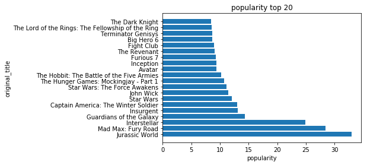

```python
# movie_data[['id', 'popularity']].head(100)
sorted_movie_data = movie_data.sort_values('popularity', ascending=False).head(20)
sorted_movie_data
# max_popularity = sorted_movie_data['popularity'].max()
# bins_edge = np.arange(0, max_popularity + 1, 1)
# sb.distplot(sorted_movie_data['popularity'])
# plt.bar(sorted_movie_data['original_title'], sorted_movie_data['popularity'])
plt.barh(sorted_movie_data['original_title'], sorted_movie_data['popularity'])
plt.xlabel('popularity')
plt.ylabel('original_title')
plt.title('popularity top 20')
```

**任务3.2：**分析电影净利润（票房-成本）随着年份变化的情况，并简单进行分析。

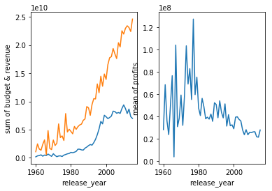

```python
# profit_by_year = movie_data.groupby(['release_year']).agg({'budget': 'sum', 'revenue': 'sum'}).sort_values('release_year')

# plt.plot(year_sorted_movie_data['release_year'], year_sorted_movie_data['revenue']  - year_sorted_movie_data['budget'])
# print(profit_by_year.head(1))
# print(profit_by_year.tail(1))
# plt.plot(profit_by_year[['budget', 'revenue']])

# plt.errorbar(profit_by_year.index, profit_by_year['budget'])
# plt.errorbar(profit_by_year.index, profit_by_year['revenue'], yerr=profit_by_year['revenue']-profit_by_year['budget'], fmt='-o')

# plt.plot(profit_by_year['revenue']-profit_by_year['budget'])

movie_data['profits'] = movie_data['revenue_adj'] - movie_data['budget_adj']
profits_by_year = movie_data.groupby('release_year')['profits'].mean()

plt.subplot(1, 2, 1)
plt.errorbar(x=profits_by_year.index, y=movie_data.groupby('release_year')['budget_adj'].sum())
plt.errorbar(x=profits_by_year.index, y=movie_data.groupby('release_year')['revenue_adj'].sum())
plt.xlabel('release_year')
plt.ylabel('sum of budget & revenue')

plt.subplot(1, 2, 2)
plt.errorbar(x=profits_by_year.index, y=profits_by_year)
plt.xlabel('release_year')
plt.ylabel('mean of profits')
```

**[选做]任务3.3：**选择最多产的10位导演（电影数量最多的），绘制他们排行前3的三部电影的票房情况，并简要进行分析。

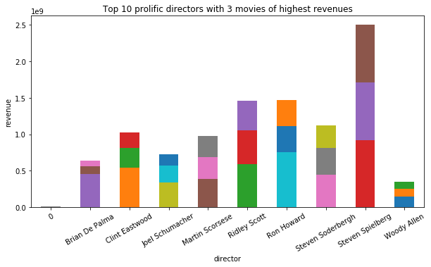

```python
# directors = movie_data[movie_data['director'] != 0].groupby(['director']).agg({'original_title': 'count'}).sort_values('original_title', ascending=False).index[0:10]

# for director in directors:
    #print(movie_data[movie_data['director'] == director].sort_values('revenue', ascending=False)[0:3][['director', 'original_title', 'revenue']])

director_data = movie_data[['director', 'original_title', 'revenue']]
# Get Most Prolific Directors
top10_directors = director_data.groupby('director').count()['original_title'].nlargest(10).index
top10_table = director_data[director_data['director'].isin(top10_directors)]
# Rearrange Table for Plotting
top10_table = top10_table.sort_values(['director','revenue'], ascending=[False,False]) \
  .set_index(['director','original_title'])
# Plot Highest Revenues
top10_table.groupby(level=0).head(3).unstack() \
  .plot(kind='bar',stacked=True, legend=False, rot=30, figsize=(10,5))
plt.ylabel('revenue')
plt.title("Top 10 prolific directors with 3 movies of highest revenues")
```

**[选做]任务3.4：**分析1968年~2015年六月电影的数量的变化。

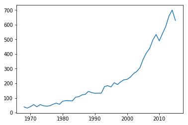

```python
films_by_year = movie_data[(movie_data['release_year'] > 1967) & (movie_data['release_year'] < 2016)]
plt.plot(films_by_year.groupby('release_year').agg({'original_title': 'count'}).sort_values('release_year'))
```

**[选做]任务3.5：**分析1968年~2015年六月电影 `Comedy` 和 `Drama` 两类电影的数量的变化。

```python
c_d_films = films_by_year[(films_by_year['genres'].str.contains('Comedy')) | (films_by_year['genres'].str.contains('Drama'))]

# c_d_films.groupby(['release_year', 'genres']).agg({'original_title': 'count'}).sort_values('release_year')
c_d_films.groupby(['release_year', 'genres']).count()['original_title']
```

```
release_year  genres
1968          Action|Crime|Drama|Thriller                        2
              Action|Drama                                       1
              Adventure|Drama|Action|History|War                 1
              Adventure|Fantasy|Comedy|Family                    1
              Comedy                                             3
              Comedy|Drama|Family                                1
              Comedy|Family|Fantasy                              1
              Comedy|Fantasy                                     1
              Crime|Drama|Mystery|Thriller                       1
              Crime|Drama|Romance|Thriller                       1
              Drama                                              4
              Drama|Comedy|Music|Romance                         1
              Drama|Family|Music                                 1
              Drama|History                                      1
              Drama|Horror|History                               1
              Drama|Romance                                      1
              Drama|Romance|Science Fiction                      1
              Fantasy|Comedy|Family                              1
              Horror|Drama|Mystery                               1
              Romance|Crime|Thriller|Drama                       1
              War|Drama                                          1
1969          Action|Adventure|Comedy|Fantasy|Science Fiction    1
              Action|Adventure|Crime|Drama                       1
              Action|Comedy|Drama|Romance|War                    1
              Action|Drama|History|War                           1
              Action|Drama|Mystery|Thriller                      1
              Animation|Comedy                                   1
              Animation|Comedy|Family                            1
              Comedy                                             2
              Comedy|Crime                                       1
                                                                ..
2015          Romance|Music|TV Movie|Comedy                      1
              Romance|War|Documentary|Drama                      1
              Science Fiction|Comedy                             1
              Science Fiction|Comedy|Animation|Family            1
              Science Fiction|Comedy|Horror                      1
              Science Fiction|Drama|Family                       1
              Science Fiction|Drama|Thriller                     1
              TV Movie|Adventure|Comedy                          1
```

[output cut: 8 more lines]

```
              Thriller|Drama|Action|Crime                        1
              Thriller|Drama|Adventure|Action|History            1
              Thriller|Drama|Comedy                              1
              Thriller|Drama|Fantasy                             1
              Thriller|Drama|Horror                              1
              Thriller|Drama|Science Fiction                     1
              Thriller|Horror|Comedy|Drama                       1
              Thriller|Mystery|Drama|Horror                      1
              Thriller|Mystery|Horror|Drama                      1
              Thriller|Romance|Drama                             1
              Thriller|TV Movie|Science Fiction|Drama            1
              War|Drama                                          1
              Western|Drama                                      1
              Western|Drama|Adventure|Thriller                   1
Name: original_title, Length: 3820, dtype: int64
```

> 注意: 当你写完了所有的代码，并且回答了所有的问题。你就可以把你的 iPython Notebook 导出成 HTML 文件。你可以在菜单栏，这样导出**File -> Download as -> HTML (.html)、Python (.py)** 把导出的 HTML、python文件 和这个 iPython notebook 一起提交给审阅者。